# act_report

## Project Report: Visualization and Insight for Dog Ratings

[figure not shown]

This report shows some of the insights gotten from the gathering of 3 datasets namely Enhanced Twitter Archive, Tweet Image Prediction and Twitter API.

The three datasets were cleaned and merged into 1 dataset which i used to perform the Exploratory Analysis on the Dog Tweets

### INSIGHT 1: The different sources of the tweet

After Analyzing the dataset, it was discovered that there are four sources/mediums of where the tweets came from. So i called out the sources using : df_cleaned.tweet_source.value_counts()

| Tweet_Source | Proportion/Percentage |
| --- | --- |
| iPhone | 2042/ 93.9% |
| Vine | 91/ 4.2% |
| Web | 31/ 1.4% |
| TweetDeck | 11/ 0.5% |

The insight gotten from the above table shows that majority of the tweets were made from an IPhone and the least of the tweets came form the TweetDeck. A visual representation of the table above is:

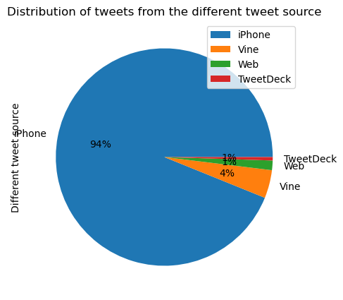

### INSIGHT 2: The distribution of the dog stages

Futher analysis provided the dog stages distribution. Some of the dogs had a specific category, some had two categories while majority of the dogs were not catagorized. The breakdown of this was gotten using: df_cleaned.dog_stage.value_counts()

| Dog Stage | Proportion(%) |
| --- | --- |
| None | 1831 (84.2%) |
| pupper | 224 (10.3%) |
| doggo | 75 (3.4%) |
| puppo | 24 (1.1%) |
| doggo&pupper | 10 (0.5%) |
| floofer | 9 (0.4%) |
| doggo&puppo | 1 (0.0%) |
| doggo&floofer | 1 (0.0%) |

This above table shows the breakdown of dog stages. Majority of the dogs were not assigned any stage while some could not be pinpointed exactly. The visual representation of the table above is shown below.

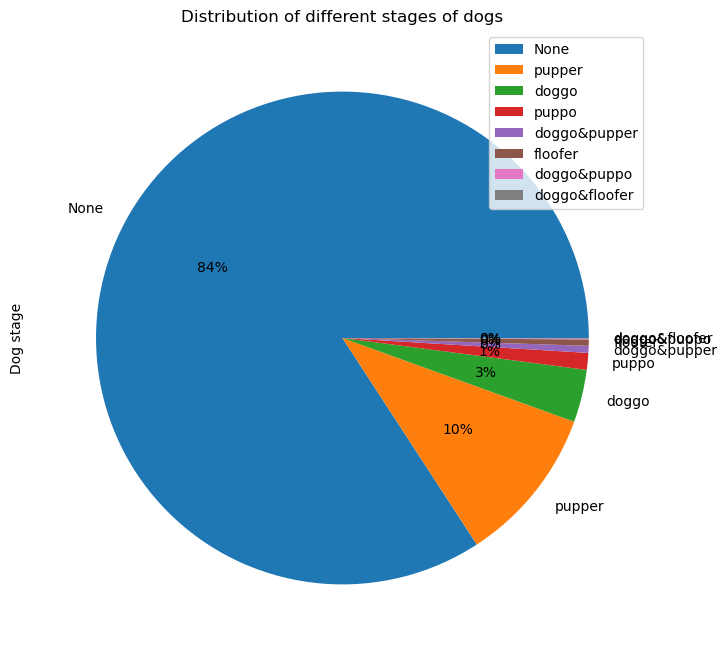

### INSIGHT 3: The most retweeted dog stage

I was able to analyse which of the dog stages had the most and least retweet with the data present. This can be used to determine which stage of dog peple were most interested in. A visual representation of that analysis is presented below:

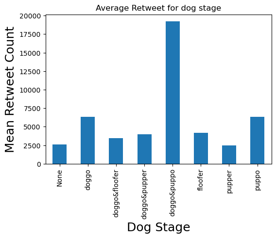

The above chart shows that most of the retweets was done for dogs in the doggo & puppo stage while the dogs that had no stage assigned and pupper stage had the least amount of retweets